# Short-term impacts of island restoration on seabirds in Gwaii Haanas (Feb. 15 update)

# BACI

Task 2e) Test whether restoration resulted in an increase in seabird vocalization metrics, by species (abundance), using BACI design.

This BACI experimental design included multiple control and impact sites, across multiple years before and after impact (i.e. rat eradication). Island groups (‘sites’) were compared and ARU locations within island groups (‘replicates’) were averaged for each site:year combination. Two response variables were considered: (1) the proportion of recordings with detection of at least one individual across a common within-season time-period (p(presence)); (2) the proportion of recordings with detection of more than one individual (i.e. overlapping calls) across a common within-season time-period (p(presence > 1). Separate BACI analyses were carried out for each species (Ancient Murrelet, Cassin’s Auklet, Fork-Tailed Storm-Petrel), eradication phase (Phase 1, Phase 2) and response (p(presence), p(presence > 1)).

### Phase 2

In phase 2, eradication of rats took place post-breeding season, 2013. There were two impact sites (Faraday, Murchison) and 4 control sites (Alder, Hotspring/House, Ramsay) and in general, 3 years of sampling before impact (2011, 2012, 2013) and 2 years of sampling after impact (2014, 2015). In total, there were 53 replciate:year combinations (after filtering out replicates that sampled outside of our time-window; see below). Replicates were located at fixed locataions across years. The sampling design was unbalanced; the number of replicates at each site ranged from 1 to 8, and replicates did not consistently sample in all years (2011-2015).

First, we constrained our anlaysis to recordings from May 01 - June 15, for each replicate:year combination. This was a period of substantial temporal overlap in replicate sampling and corresponds to a period of high vocalization activity for all species considered (ANMU, CAAU, FTSP; see previous section), which we assume indicates relative equilibrium in the breeding population (i.e. minimal permanent ingress/egress of breeders). This excluded 3 of 56 replicate:year combinations: NBR_21_ALDE:2014 (03-20: 04-26); NBR26_MURC:2012 (06-18: 08-18); NBR34_FARA:2012 (06-18: 08-17) and reduced the total number of 10-minute recoring samples from 326,012 to 117,168.

We fit a mixed effects model using the lmer() function within the lme4 package. A model was fit with fixed effects period (Before/After), siteclass (Control/Impact), and period:siteclass interaction; random effects included year and island. We used ANOVA (type 3 with Kenward-Roger approximation for degrees of freedom) to determine statistical significance of fixed effects. A p-value < 0.05 for the interacation term indicated presence of a BACI effect. We determined the magnitude of the BACI effect by estimating marginal means and determining 95% Confidence Intervals (CI); CI including 0 indicated no effect.

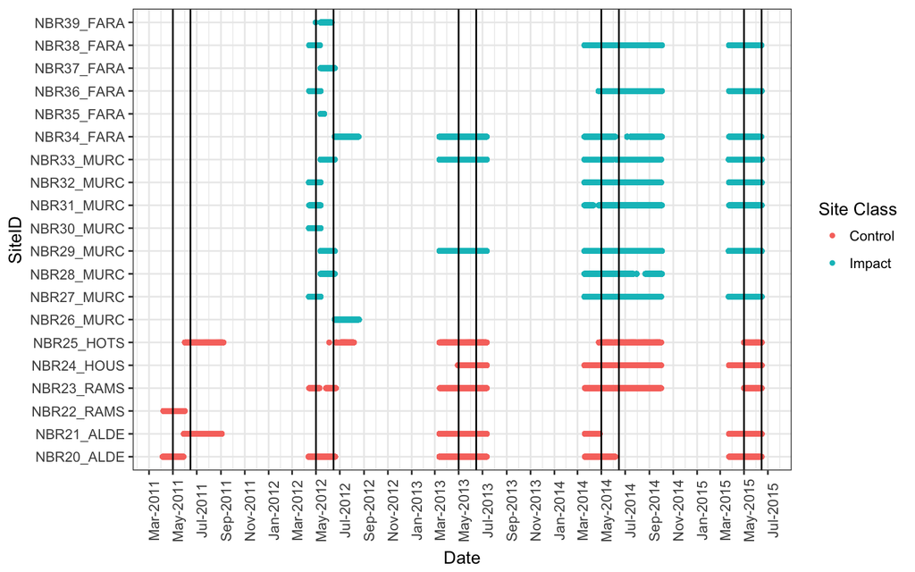

Figure 1: Temporal coverage of each location with ARU (i.e. ‘replicate’). Colour indicates whether replicate is located on a control or impact island. Vertical black lines indiacte sampling window used for analysis.

### Ancient Murrelet

#### Presence of >= 1 individual

##### Mean proportion and standard deviation values for all site:year combinations.

| Year | IslandGroup | SiteClass | Period | n | MeanProportion | SdProportion |
| --- | --- | --- | --- | --- | --- | --- |
| 2011 | Alder | Control | Before | 2 | 0.8504355 | 0.1610085 |
| 2011 | Hotspring | Control | Before | 1 | 0.0295858 | NA |
| 2012 | Alder | Control | Before | 1 | 0.7953144 | NA |
| 2012 | Faraday | Impact | Before | 5 | 0.0000000 | 0.0000000 |
| 2012 | Hotspring | Control | Before | 1 | 0.0000000 | NA |
| 2012 | Murchison | Impact | Before | 7 | 0.0339646 | 0.0574324 |
| 2012 | Ramsay | Control | Before | 1 | 0.5233266 | NA |
| 2013 | Alder | Control | Before | 2 | 0.7983029 | 0.1061583 |
| 2013 | Faraday | Impact | Before | 1 | 0.0339426 | NA |
| 2013 | Hotspring | Control | Before | 1 | 0.0757180 | NA |
| 2013 | House | Control | Before | 1 | 0.7741514 | NA |
| 2013 | Murchison | Impact | Before | 2 | 0.0456919 | 0.0166161 |
| 2013 | Ramsay | Control | Before | 1 | 0.7624021 | NA |
| 2014 | Alder | Control | After | 1 | 0.9163880 | NA |
| 2014 | Faraday | Impact | After | 3 | 0.0005574 | 0.0009655 |
| 2014 | Hotspring | Control | After | 1 | 0.0013298 | NA |
| 2014 | House | Control | After | 1 | 0.6622340 | NA |
| 2014 | Murchison | Impact | After | 6 | 0.0109303 | 0.0159358 |
| 2014 | Ramsay | Control | After | 1 | 0.7034574 | NA |
| 2015 | Alder | Control | After | 2 | 0.9135518 | 0.0215178 |
| 2015 | Faraday | Impact | After | 3 | 0.0245313 | 0.0232135 |
| 2015 | Hotspring | Control | After | 1 | 0.1016636 | NA |
| 2015 | House | Control | After | 1 | 0.9371534 | NA |
| 2015 | Murchison | Impact | After | 5 | 0.0627409 | 0.0745188 |
| 2015 | Ramsay | Control | After | 1 | 0.9284404 | NA |

##### Test homogeneity of standard deviation across mean

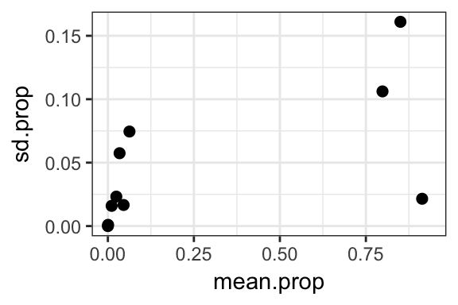

Figure 2: Standard Deviation against mean p(presence) at replicates for each site

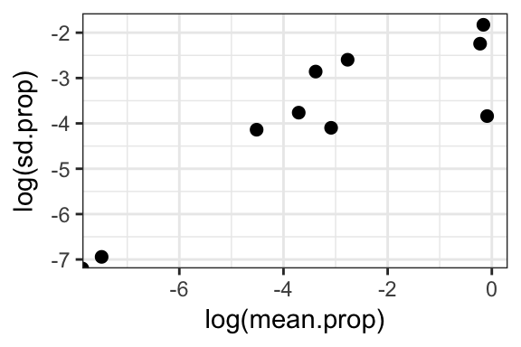

Figure 2: Standard Deviation against mean p(presence) at replicates for each site

##### Plot BACI results

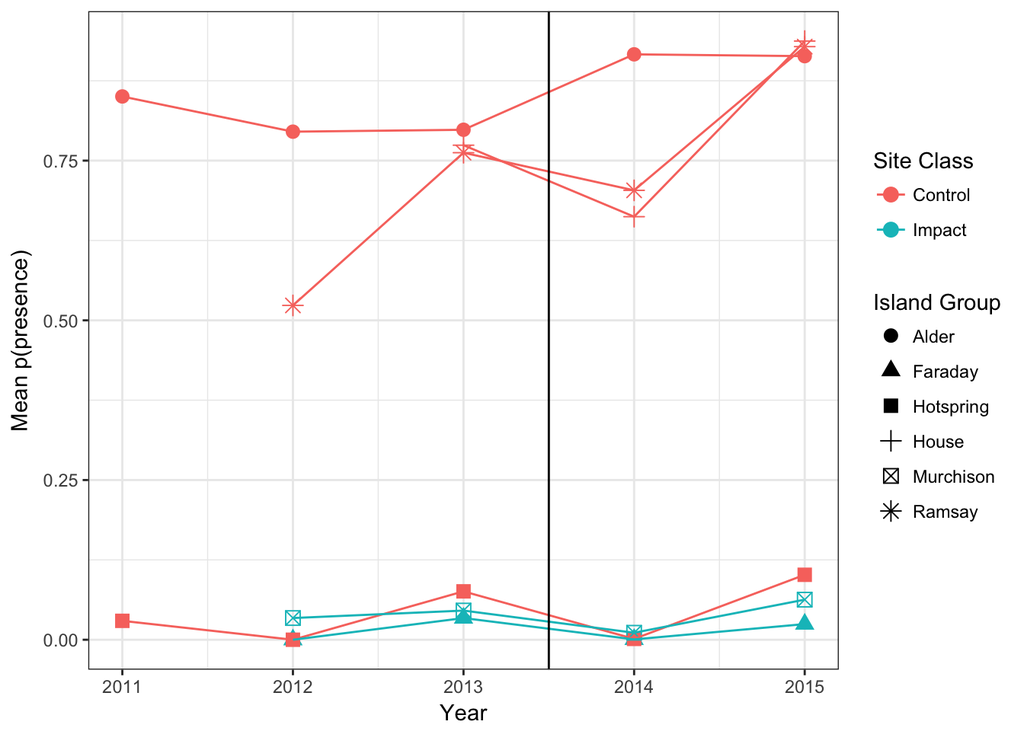

Figure 3: Mean proportion of recordings with detection of at least one individual at repicates for each island group. Color indicates whether island was control or impact; shape indicates island group

##### Model results

Model for demonstration (will not be in final report): lmer.anmu.ph2.1 <- lmerTest::lmer(mean.prop ~ period + exp + period:exp + (1|yearf) + (1|island), data = mean.anmu) summary(lmer.anmu.ph2.1)

|  | Estimate | Std. Error | df | t value | Pr(>\|t\|) |
| --- | --- | --- | --- | --- | --- |
| Intercept | 0.6035826 | 0.1637720 | 4.187209 | 3.685506 | 0.0194703 |
| Period | 0.0593187 | 0.0416451 | 3.811074 | 1.424384 | 0.2308061 |
| SiteClass | -0.5737388 | 0.2805922 | 4.013490 | -2.044742 | 0.1101119 |
| Period:SiteClass | -0.0666073 | 0.0417053 | 14.753152 | -1.597095 | 0.1314373 |

Marginal means

[output not shown]

| island | (Intercept) | NA | 0.1038164 | 0.3222056 |
| --- | --- | --- | --- | --- |
| yearf | (Intercept) | NA | 0.0027685 | 0.0526164 |
| Residual | NA | NA | 0.0045579 | 0.0675119 |